# Proteomics-Based Patient Stratification of Pediatric Brain Tumours

CPTAC/CHOP Brain Cancer Cohort (brain_cptac_2020)

2026-04-15

## Overview

This notebook reproduces and extends the proteomics-based patient stratification from Petralia et al. (Cell, 2020) using the publicly available CPTAC/CHOP pediatric brain cancer dataset (`brain_cptac_2020` on cBioPortal).

**Dataset:** 218 tumour samples from 199 patients across 7 histological subtypes  
(LGG, Ependymoma, HGG, Medulloblastoma, Ganglioglioma, Craniopharyngioma, ATRT),  
each with WGS, RNA-seq, global proteomics, and phosphoproteomics.

**Why proteomics?**  
Unlike sparse binary mutation profiles (which need network smoothing to be informative), proteomics data is already a dense, continuous, pathway-integrated signal. It directly captures the functional downstream consequences of mutations, splicing, and post-translational regulation. In a sense, the “smoothed” output that NBS tries to recover from mutations.

**Pipeline summary:**

```
Local data files
    │ load + clean column names
    v
Quality control
    │ remove high-missing proteins, KNN imputation, PCA sanity check
    v
Dimensionality reduction
    │ top 50 PCs, shift to non-negative for NMF
    v
k selection
    │ cophenetic correlation, dispersion, silhouette across k = 2–8
    v
Consensus NMF clustering
    │ 60 runs per k, consensus matrix, final cluster labels
    v
Biological validation
    ├── Kaplan–Meier survival (log-rank test)
    ├── Histological composition per cluster
    └── Differential protein expression (limma one-vs-rest)
```

## 1. Packages & Configuration

```r
# Core
library(tidyverse) # dplyr, ggplot2, tidyr, purrr, stringr
library(janitor) # clean_names() for consistent column naming

# Matrix / imputation
library(impute) # KNN imputation for missing proteomics values (Bioconductor)

# Clustering
library(NMF) # Non-negative matrix factorisation + consensus clustering
library(cluster) # silhouette scores
library(pheatmap) # annotated heatmaps
library(RColorBrewer) # colour palettes

# PCA visualisation (only used for k selection)
#library(factoextra) # fviz_eig() scree plot helper

# Survival
library(survival) # Surv(), survfit(), coxph()
library(survminer) # ggsurvplot()

# Differential expression
library(limma) # linear models for proteomics; well-validated on MS data
```

```r
# Global parameters
set.seed(42)

DATA_DIR <- "./brain_cptac_2020" # folder with downloaded cBioPortal files
MISSING_THRESHOLD <- 0.30 # remove proteins missing in > 30% of samples
N_PCS <- 50 # PCA components fed into NMF (same as paper)
K_MIN <- 2 # minimum k to test
K_MAX <- 8 # maximum k to test
NMF_RUNS <- 60 # NMF initializations per k (more = more stable, 60 matches paper)

cat("Configuration ready. Data directory:", DATA_DIR)
```

```
Configuration ready. Data directory: ./brain_cptac_2020
```

## 2. Data Loading

We read four flat files downloaded from cBioPortal. All files live in `DATA_DIR`.  
Column names are cleaned with `janitor::clean_names()` for consistent `snake_case`.

```r
# Clinical (patient-level)
clin_raw <- read.delim(
  file.path(DATA_DIR, "data_clinical_patient.txt"),
  comment.char = "#", sep = "\t", header = TRUE, check.names = FALSE,
  stringsAsFactors = FALSE
) |> janitor::clean_names()

# Clinical (sample-level)
samples_raw <- read.delim(
  file.path(DATA_DIR, "data_clinical_sample.txt"),
  comment.char = "#", sep = "\t", header = TRUE, check.names = FALSE,
  stringsAsFactors = FALSE
) |> janitor::clean_names()

# Proteomics (proteins × samples z-scores)
prot_raw <- read.delim(
  file.path(DATA_DIR, "data_protein_quantification.txt"),
  comment.char = "#", sep = "\t", header = TRUE, check.names = FALSE,
  stringsAsFactors = FALSE
) |> janitor::clean_names()

# Somatic mutations
mut_raw <- read.delim(
  file.path(DATA_DIR, "data_mutations.txt"),
  comment.char = "#", sep = "\t", header = TRUE, check.names = FALSE,
  stringsAsFactors = FALSE
) |> janitor::clean_names()

cat("Files loaded.\n")
```

```
Files loaded.
```

```r
cat("  Clinical patients :", nrow(clin_raw), "rows\n")
```

```
  Clinical patients : 199 rows
```

```r
cat("  Clinical samples:", nrow(samples_raw), "rows\n")
```

```
  Clinical samples: 218 rows
```

```r
cat("  Proteomics rows:", nrow(prot_raw), "(should equal n_proteins)\n")
```

```
  Proteomics rows: 6429 (should equal n_proteins)
```

```r
cat("  Mutations rows:", nrow(mut_raw))
```

```
  Mutations rows: 9951
```

```r
# Build proteomics matrix (samples × proteins)
# The file is formatted as proteins × samples with the first column being the
# protein identifier. We transpose so rows = samples, columns = proteins.
# R prepends 'x' to numeric-starting column names; we strip that and convert
# underscores back to hyphens to match the sample IDs in the sample file.

prot_wide <- prot_raw |>
  column_to_rownames("composite_element_ref") |> # protein IDs to rownames
  select(where(~ sum(!is.na(.)) > 0)) |> # drop all-NA columns
  as.matrix() |> t() # now: samples × proteins

storage.mode(prot_wide) <- "numeric"


# Fix rownames: "x7316_1781" to "7316-1781"
rownames(prot_wide) <- rownames(prot_wide) |>
  str_remove("^x") |>
  str_replace_all("_", "-")


# Parse survival from patient-level clinical
# os_status is formatted as "1:DECEASED" or "0:LIVING"
clinical <- clin_raw |>
  mutate(
    os_event  = as.integer(str_detect(toupper(os_status), "DECEASED|1:DECEASED")),
    os_months = suppressWarnings(as.numeric(os_months)))


# Build unified sample table
# Joins sample-level info (histology, tumour type) with patient-level survival
samples <- samples_raw |>
  select(sample_id, patient_id, cancer_type_detailed,
         tumor_type, age_at_specimen_diagnosis) |>
  left_join(
    select(clinical, patient_id, os_months, os_event, sex),
    by = "patient_id")

cat("Proteomics matrix:", nrow(prot_wide), "samples ×", ncol(prot_wide), "proteins\n")
```

```
Proteomics matrix: 218 samples × 6429 proteins
```

```r
cat("Patients with OS data:", sum(!is.na(clinical$os_months)), "\n")
```

```
Patients with OS data: 192
```

```r
cat("Events (deaths):", sum(clinical$os_event, na.rm = TRUE), "\n")
```

```
Events (deaths): 40
```

```r
cat("Histological subtypes:")
```

```
Histological subtypes:
```

```r
samples |> count(cancer_type_detailed, sort = TRUE) |> print()
```

| cancer_type_detailed | n |
| --- | --- |
| Pediatric Low Grade Gliomas | 93 |
| Ependymomal Tumor | 32 |
| Pediatric High Grade Gliomas | 25 |
| Medulloblastoma | 22 |
| Ganglioglioma | 18 |
| Craniopharyngioma, Adamantinomatous Type | 16 |
| Atypical Teratoid/Rhabdoid Tumor | 12 |

## 3. Quality Control

Two systematic issues in mass-spectrometry proteomics must be addressed before clustering:

1. **Missing values**: proteins below the detection limit are absent. Missingness is non-random (low-abundance proteins drop out more). We remove proteins missing in > `MISSING_THRESHOLD` of samples, then impute remaining NAs with KNN imputation.
2. **Outlier samples**: samples missing > 40% of the remaining proteins likely reflect technical failures.

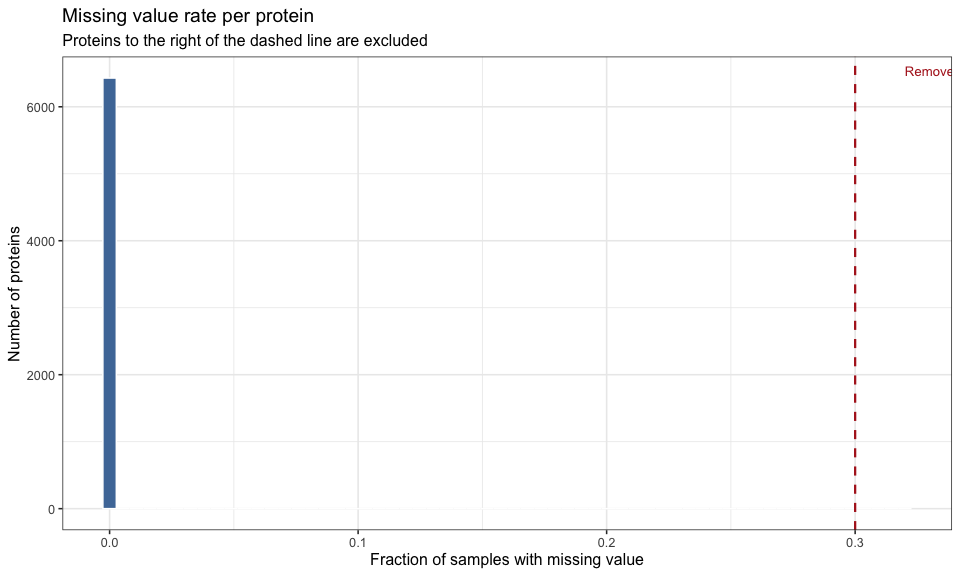

```r
# Per-protein and per-sample missing rates
missing_per_protein <- colMeans(is.na(prot_wide))
missing_per_sample <- rowMeans(is.na(prot_wide))

# Distribution of missing rates across proteins
data.frame(missing_rate = missing_per_protein) |>
  ggplot(aes(x = missing_rate)) +
  geom_histogram(bins = 60, fill = "#4E79A7", colour = "white") +
  geom_vline(xintercept = MISSING_THRESHOLD,
             colour = "firebrick", linetype = "dashed", linewidth = 0.8) +
  annotate("text",
           x = MISSING_THRESHOLD + 0.02, y = Inf,
           label = paste0("Remove if > ", MISSING_THRESHOLD * 100, "% missing"),
           colour = "firebrick", vjust = 2, hjust = 0, size = 3.5) +
  labs(title = "Missing value rate per protein",
       subtitle = "Proteins to the right of the dashed line are excluded",
       x = "Fraction of samples with missing value", y = "Number of proteins") +
  theme_bw(base_size = 12)
```

```r
# 1. Remove high-missing proteins
prot_filtered <- prot_wide[, missing_per_protein <= MISSING_THRESHOLD]
cat(sprintf("Proteins removed (> %d%% missing): %d | Remaining: %d\n",
            as.integer(MISSING_THRESHOLD * 100),
            ncol(prot_wide) - ncol(prot_filtered),
            ncol(prot_filtered)))
```

```
Proteins removed (> 30% missing): 0 | Remaining: 6429
```

```r
# 2. Remove outlier samples
outlier_samples <- names(missing_per_sample[missing_per_sample > 0.40])
if (length(outlier_samples) > 0) {
  cat("Outlier samples removed:", paste(outlier_samples, collapse = ", "), "\n")
  prot_filtered <- prot_filtered[!rownames(prot_filtered) %in% outlier_samples, ]
} else {
  cat("No outlier samples detected.\n")}
```

```
No outlier samples detected.
```

```r
# 3. KNN imputation for remaining NAs
# impute.knn() expects features as rows, samples as columns → transpose twice.
# k = 10 neighbours is standard for proteomics datasets of this size.
cat("Running KNN imputation (k = 10)...\n")
```

```
Running KNN imputation (k = 10)...
```

```r
prot_imputed <- prot_filtered |>
  t() |>
  impute.knn(k = 10) |>
  _$data |> t()
```

```
Cluster size 6429 broken into 5848 581
Cluster size 5848 broken into 3800 2048
Cluster size 3800 broken into 678 3122
Done cluster 678
Cluster size 3122 broken into 22 3100
Done cluster 22
Cluster size 3100 broken into 1999 1101
Cluster size 1999 broken into 934 1065
Done cluster 934
Done cluster 1065
Done cluster 1999
Done cluster 1101
Done cluster 3100
Done cluster 3122
Done cluster 3800
Cluster size 2048 broken into 1275 773
Done cluster 1275
Done cluster 773
Done cluster 2048
Done cluster 5848
Done cluster 581
```

```r
cat("Final matrix after QC:", nrow(prot_imputed), "samples ×",
    ncol(prot_imputed), "proteins")
```

```
Final matrix after QC: 218 samples × 6429 proteins
```

## 4. Dimensionality Reduction (PCA to NMF input)

This linear shift preserves all pairwise distances.

```r
# Scale proteins before PCA (proteomics data should be z-scored column-wise)
prot_scaled <- scale(prot_imputed)

# PCA
pca_res <- prcomp(prot_scaled, scale. = FALSE)
var_expl <- round(100 * pca_res$sdev^2 / sum(pca_res$sdev^2), 2)

cat(sprintf("Top 3 PCs explain %.1f%% of total variance.\n",
            sum(var_expl[1:3])))
```

```
Top 3 PCs explain 41.8% of total variance.
```

```r
cat(sprintf("Top %d PCs explain %.1f%% of total variance.",
            N_PCS, sum(var_expl[1:N_PCS])))
```

```
Top 50 PCs explain 81.7% of total variance.
```

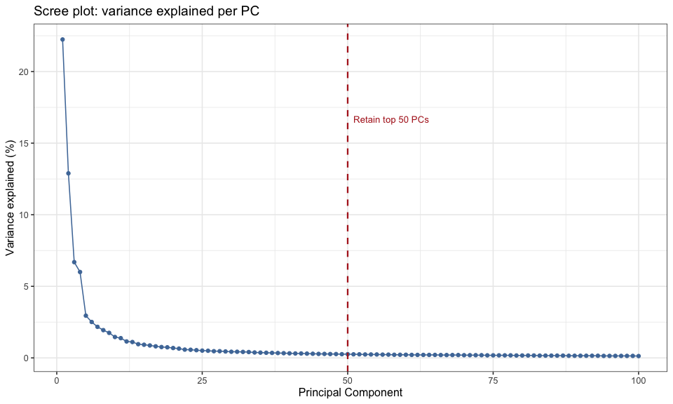

```r
data.frame(PC = seq_along(var_expl), variance = var_expl) |>
  filter(PC <= 100) |>
  ggplot(aes(x = PC, y = variance)) +
  geom_line(colour = "#4E79A7") +
  geom_point(size = 1.5, colour = "#4E79A7") +
  geom_vline(xintercept = N_PCS, linetype = "dashed",
             colour = "firebrick", linewidth = 0.8) +
  annotate("text", x = N_PCS + 1, y = max(var_expl) * 0.75,
           label = paste0("Retain top ", N_PCS, " PCs"),
           colour = "firebrick", hjust = 0, size = 3.5) +
  labs(title = "Scree plot: variance explained per PC",
       x = "Principal Component", y = "Variance explained (%)") +
  theme_bw(base_size = 12)
```

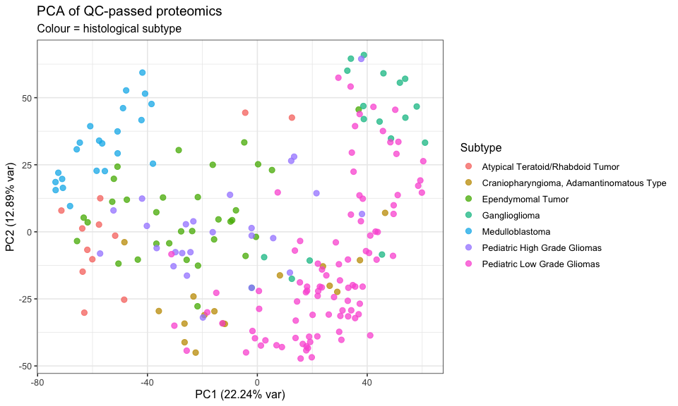

```r
# Visualise PC1 vs PC2, coloured by histological subtype
pca_df <- as.data.frame(pca_res$x[, 1:5]) |>
  rownames_to_column("sample_id") |>
  left_join(select(samples, sample_id, cancer_type_detailed), by = "sample_id")

ggplot(pca_df, aes(x = PC1, y = PC2, colour = cancer_type_detailed)) +
  geom_point(alpha = 0.75, size = 2.5) +
  labs(title = "PCA of QC-passed proteomics",
       subtitle = "Colour = histological subtype",
       x = paste0("PC1 (", var_expl[1], "% var)"),
       y = paste0("PC2 (", var_expl[2], "% var)"),
       colour = "Subtype") +
  theme_bw(base_size = 12)
```

```r
# Extract top N_PCS PC scores and shift to non-negative for NMF
pca_scores <- pca_res$x[, 1:N_PCS]
pca_scores_nn <- pca_scores - min(pca_scores) # shift smallest value to 0

cat("NMF input matrix:", nrow(pca_scores_nn), "samples ×",
    ncol(pca_scores_nn), "PCs\n")
```

```
NMF input matrix: 218 samples × 50 PCs
```

```r
cat("Value range: [", round(min(pca_scores_nn), 3), ",",
    round(max(pca_scores_nn), 3), "]")
```

```
Value range: [ 0 , 142.043 ]
```

## 5. Selecting the Number of Clusters (k)

**NOTE**

Since the current automatic detection tends to select low values for k (which don’t work well with the rest of the pipeline), the notebook has been manually set to use the same k value as the paper (`k = 8`). This number of clusters k was determined by evaluating the cophenetic correlation coefficient across possible k values. `k = 8` showed the highest coefficient, indicating the most robust and stable clustering where samples reliably grouped together. This should aid in our analysis. Some chunks are now useless, as their purpose was to aid in k selection, so they’ve been turned off. To run and see them in the Knit, remove `eval=FALSE` and `echo=FALSE`.

**Automated k selection**

We sweep k from `K_MIN` to `K_MAX` and evaluate three complementary stability metrics from the NMF consensus:

- **Cophenetic correlation**: how faithfully the consensus matrix preserves sample distances (close to 1 = stable)
- **Dispersion**: how bimodal the consensus matrix is (values near 0 or 1)
- **Silhouette score**: how well-separated clusters are in feature space

The best k shows a consistent peak or elbow across all three. We prefer the silhouette score as the primary criterion because it directly measures biological cluster separability.

```r
# Manual override:
# To use the k from the published paper (k = 8) instead, uncomment:
BEST_K <- 8
```

## 6. Consensus NMF Clustering

With `BEST_K` chosen, we run a final NMF and extract the consensus matrix and cluster labels.

**Interpreting the consensus heatmap:**

- Dark blue diagonal blocks indicate patients always cluster together (stable)
- Light off-diagonal regions indicate patients from different clusters never co-cluster (good separation)
- Mixed histologies within a cluster indicate cross-boundary molecular grouping, a key finding of the original paper

```r
nmf_best <- nmf(
  pca_scores_nn,
  rank = BEST_K,
  nrun = NMF_RUNS,
  seed = 42,
  method = "brunet",
  .options = "vr")
```

```
Runs: |
Runs: |                                                  |   0%
Runs: |
Runs: |==================================================| 100%
System time:
   user  system elapsed
 37.939   2.414  21.041
```

```r
# Extract consensus matrix
cons_matrix <- consensus(nmf_best) # samples × samples, values in [0, 1]

# Assign each sample to the cluster with its highest NMF basis weight.
# We use basis() rather than predict() here: predict() assigns to the
# component with the highest H-matrix value, which can collapse to a single
# cluster when one component dominates. basis() scores are per-sample and
# more reliably reflect the consensus structure.
basis_mat <- basis(nmf_best) # 218 samples × k
cluster_labels <- apply(basis_mat, 1, which.max) # argmax across columns
names(cluster_labels) <- rownames(pca_scores_nn) # 218 real sample IDs

cat("Cluster distribution:\n")
```

```
Cluster distribution:
```

```r
print(table(cluster_labels))
```

```
cluster_labels
 1  2  3  4  5  6  7  8
39  8 24 53 39 25 16 14
```

```r
# NOTE: `basis_mat` used to be called `basis`, in case of downstream issues.
```

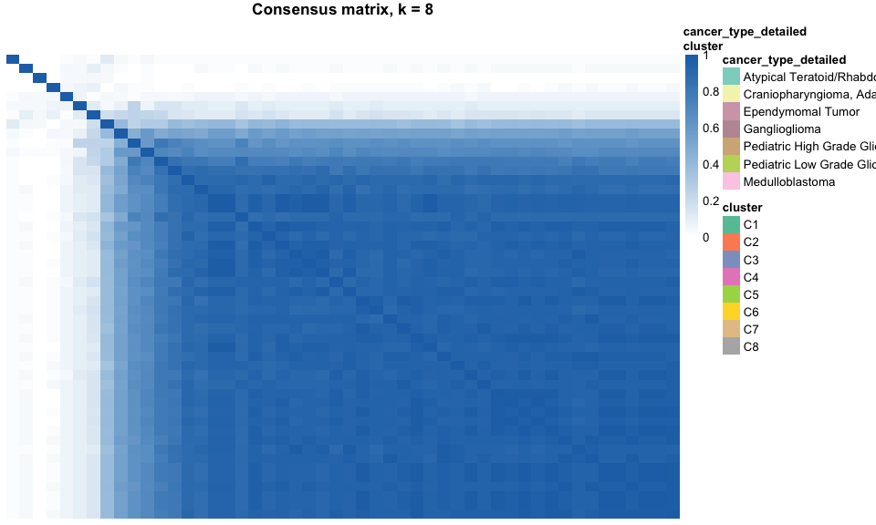

```r
# Annotation data frame for the heatmap
sample_ann <- tibble(sample_id = names(cluster_labels),
                     cluster = paste0("C", cluster_labels)) |>
  left_join(select(samples, sample_id, cancer_type_detailed), by = "sample_id") |>
  column_to_rownames("sample_id")

# Colour palettes
cluster_colours <- setNames(
  brewer.pal(max(BEST_K, 3), "Set2")[1:BEST_K],
  paste0("C", 1:BEST_K))
subtypes_present <- unique(sample_ann$cancer_type_detailed)
subtype_colours <- setNames(
  colorRampPalette(brewer.pal(8, "Set3"))(length(subtypes_present)),
  subtypes_present)

# Sort by cluster using the cons_matrix row order
# to guarantee the annotation and matrix rows stay aligned
sample_order <- order(cluster_labels[rownames(cons_matrix)]) # match cons_matrix
cons_matrix_ordered <- cons_matrix[sample_order, sample_order]

# Plot with ordered matrix
pheatmap(
  cons_matrix_ordered, # use ordered matrix
  cluster_rows = FALSE, cluster_cols = FALSE,
  annotation_col = sample_ann[rownames(cons_matrix)[sample_order], ], # match annotation order
  annotation_colors = list(cluster = cluster_colours, cancer_type_detailed = subtype_colours),
  color = colorRampPalette(c("white", "#2171B5"))(100),
  border_color = NA, show_rownames = FALSE, show_colnames = FALSE,
  main = paste0("Consensus matrix, k = ", BEST_K),
  fontsize = 10
)
```

```r
# Build a unified cluster data frame merging labels, histology, and survival
cluster_df <- tibble(
  sample_id = names(cluster_labels),
  cluster   = as.integer(cluster_labels)) |>
  left_join(
    select(samples, sample_id, patient_id, cancer_type_detailed,
           tumor_type, os_months, os_event),
    by = "sample_id")

cat("Cluster sizes:\n")
```

```
Cluster sizes:
```

```r
cluster_df |> count(cluster) |> print()
```

| cluster | n |
| --- | --- |
| 1 | 39 |
| 2 | 8 |
| 3 | 24 |
| 4 | 53 |
| 5 | 39 |
| 6 | 25 |
| 7 | 16 |
| 8 | 14 |

```r
cat("Missing os_months:", sum(is.na(cluster_df$os_months)))
```

```
Missing os_months: 7
```

## 7. Survival Analysis

A key clinical test: do the identified subgroups have different survival outcomes?  
We use Kaplan–Meier curves and the log-rank test. A significant p-value (< 0.05) means the clusters capture clinically meaningful biology, not just abstract molecular similarity.

```r
# For patients with multiple samples, keep only one row per patient
surv_data <- cluster_df |>
  filter(!is.na(os_months) & os_months > 0) |>
  group_by(patient_id) |> slice(1) |> ungroup() |>
  mutate(cluster = factor(paste0("C", cluster)),
          # Convert months to days for clinical standard display (365.25/12 = 30.44)
          os_days  = os_months * 30.44) # matches clinical oncology standard (365.25/12)

cat("Patients:", nrow(surv_data), "Events:", sum(surv_data$os_event))
```

```
Patients: 187 Events: 37
```

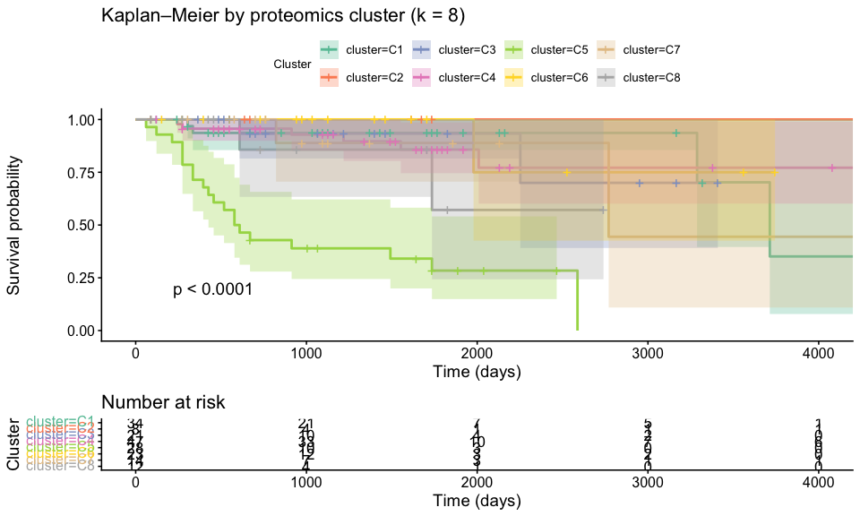

```r
# Kaplan–Meier curves using survminer (ggplot2-based)
fit <- survfit(Surv(os_days, os_event) ~ cluster, data = surv_data)

ggsurvplot(
  fit,
  data = surv_data,
  pval = TRUE, # adds log-rank p-value
  conf.int = TRUE,
  risk.table = TRUE, # number at risk table below the plot
  palette = "Set2",
  legend.title = "Cluster",
  xlab = "Time (days)",
  ylab = "Survival probability",
  title = paste0("Kaplan–Meier by proteomics cluster (k = ", BEST_K, ")"),
  xlim = c(0, 4000),
  break.time.by = 1000
)
```

```r
# Cox proportional hazards model
# Controls for age (at diagnosis) and sex so we can test whether the cluster effect
# on survival is independent of known clinical covariates.
# Age: use `age_at_initial_diagnosis` from the patient file.
# Sex: encode as a two-level factor; treat missing/empty as NA and drop.
cox_data <- surv_data |>
  left_join(
    clinical |> select(patient_id, age_at_initial_diagnosis, sex),
    by = "patient_id") |>
  mutate(
    age = suppressWarnings(as.numeric(age_at_initial_diagnosis)),
    # Standardise sex labels; blank strings become NA
    sex = na_if(trimws(sex), "") |> factor()) |>
  filter(!is.na(age)) # drop the small number of rows with no age data

cat(sprintf("Cox model: %d patients (%d events), %d clusters\n",
            nrow(cox_data), sum(cox_data$os_event), nlevels(cox_data$cluster)))
```

```
Cox model: 187 patients (37 events), 8 clusters
```

```r
cox_fit <- coxph(
  Surv(os_days, os_event) ~ cluster + age + sex,
  data = cox_data
)

# Tidy coefficient table
summary(cox_fit)$coefficients |>
  as.data.frame() |>
  rownames_to_column("term") |>
  select(term, coef, `exp(coef)`, `se(coef)`, `Pr(>|z|)`) |>
  rename(log_HR = coef, HR = `exp(coef)`, SE = `se(coef)`, p_value = `Pr(>|z|)`) |>
  mutate(across(where(is.numeric), ~ round(., 4))) |>
  print()
```

| term | log_HR | HR | SE | p_value |
| --- | --- | --- | --- | --- |
| clusterC2 | -16.8291 | 0.0000 | 4806.1043 | 0.9972 |
| clusterC3 | -0.0550 | 0.9464 | 0.8691 | 0.9495 |
| clusterC4 | -0.0482 | 0.9529 | 0.6489 | 0.9408 |
| clusterC5 | 2.3549 | 10.5369 | 0.5686 | 0.0000 |
| clusterC6 | -1.0302 | 0.3569 | 1.1253 | 0.3599 |
| clusterC7 | 0.3445 | 1.4113 | 0.8719 | 0.6928 |
| clusterC8 | 0.9092 | 2.4823 | 0.8790 | 0.3010 |
| age | 0.0001 | 1.0001 | 0.0001 | 0.0727 |
| sexMale | -0.0832 | 0.9202 | 0.3424 | 0.8081 |

```r
cat(sprintf("Cox model concordance: %.3f\n",
            summary(cox_fit)$concordance["C"]))
```

```
Cox model concordance: 0.814
```

**Interpreting the Cox output:**

- HR > 1 = higher hazard (worse survival) relative to C1 (reference).
- HR < 1 = lower hazard (better survival).

**C2 caveat:** C2 contains only 8 samples with very few or zero events. Its HR ≈ 0 with an enormous SE (~4800) is a Hauck–Donner / complete-separation artefact, i.e., the model cannot estimate this coefficient reliably. That means C2’s coefficient’s are uninformative; the concordance statistic (C ≈ 0.81) reflects the model’s overall discriminatory power and is the more trustworthy summary.

## 8. Biological Characterisation

### 8.1. Histological Composition per Cluster

Do the proteomics-derived clusters recapitulate known histology, or do they reveal cross-boundary groupings?

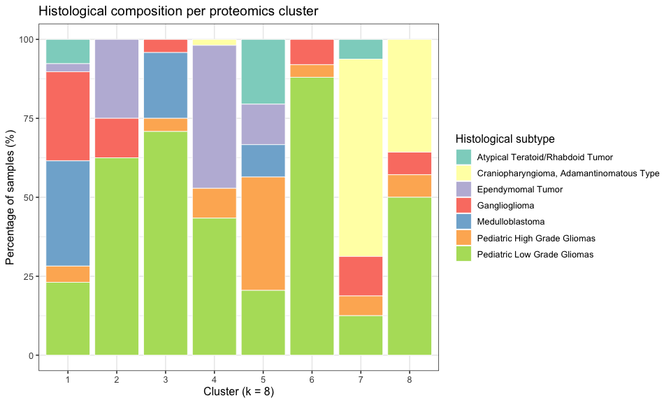

```r
cluster_df |>
  filter(!is.na(cancer_type_detailed)) |>
  count(cluster, cancer_type_detailed) |>
  group_by(cluster) |>
  mutate(pct = n / sum(n) * 100) |>
  ungroup() |>
  ggplot(aes(x = factor(cluster), y = pct,
             fill = cancer_type_detailed)) +
  geom_col(colour = "white", linewidth = 0.3) +
  scale_fill_brewer(palette = "Set3") +
  labs(title = "Histological composition per proteomics cluster",
       x = paste0("Cluster (k = ", BEST_K, ")"),
       y = "Percentage of samples (%)",
       fill = "Histological subtype") +
  theme_bw(base_size = 12)
```

**What to look for:** Clusters that are dominated by a single histological subtype (e.g. a cluster that is ~100% Medulloblastoma) are mostly recapitulating known diagnoses. Clusters that mix several subtypes, for example LGG alongside Ependymoma, are more interesting (and common here): they suggest a shared underlying molecular programme that cuts across classical histological boundaries, which is the central finding of Petralia et al. (2020).

### 8.2. Differential Protein Expression (limma one-vs-rest)

We identify proteins significantly up-regulated in each cluster relative to all other clusters combined. These become the molecular fingerprints of each subtype.

`limma` is well-validated for mass-spectrometry proteomics data (continuous, approximately normal after z-scoring) and handles the moderate sample sizes of this dataset well.

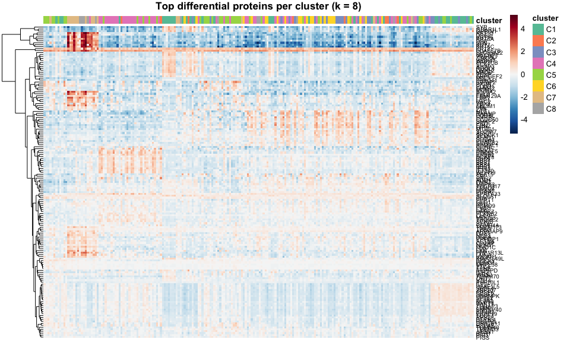

```r
# Align protein matrix to cluster assignment
common_samples <- intersect(rownames(prot_imputed), names(cluster_labels))
prot_cl <- prot_imputed[common_samples, ]
cl_vec <- cluster_labels[common_samples]

# Strip the redundant "|GENENAME" suffix that cBioPortal appends to some IDs
# e.g. "ERBB2|ERBB2" to "ERBB2"
colnames(prot_cl) <- str_remove(colnames(prot_cl), "\\|.*$")

# Collect top markers for each cluster
top_markers_all <- list()

for (cl in sort(unique(cl_vec))) {
  # Binary contrast: this cluster (1) vs all others (0)
  group <- ifelse(cl_vec == cl, "Target", "Other")
  design_mat <- model.matrix(~ 0 + factor(group))
  colnames(design_mat) <- c("Other", "Target")
  contrast_mat <- makeContrasts(Target - Other, levels = design_mat)

  fit <- lmFit(t(prot_cl), design_mat)
  fit_c <- contrasts.fit(fit, contrast_mat)
  fit_eb <- eBayes(fit_c)

  top_tbl <- topTable(fit_eb, coef = 1, n = 20, sort.by = "B", adjust.method = "BH")
  top_markers_all[[as.character(cl)]] <- rownames(top_tbl)}

# Heatmap: top markers across all clusters
all_markers <- unique(unlist(top_markers_all))

pheatmap(
  t(prot_cl[, all_markers]),
  annotation_col = data.frame(
    cluster = paste0("C", cl_vec),
    row.names = names(cl_vec)),
  annotation_colors = list(cluster = cluster_colours),
  color = colorRampPalette(rev(brewer.pal(11, "RdBu")))(100),
  cluster_rows = TRUE,
  cluster_cols = FALSE,
  show_colnames = FALSE,
  fontsize_row = 7,
  main = paste0("Top differential proteins per cluster (k = ", BEST_K, ")"),
  border_color = NA)
```

```r
cat("Top 10 upregulated marker proteins per cluster:\n")
```

```
Top 10 upregulated marker proteins per cluster:
```

```r
for (cl in names(top_markers_all)) {
  cat(sprintf("\n  Cluster %s: %s\n", cl,
              paste(top_markers_all[[cl]][1:10], collapse = ", ")))}
```

```
  Cluster 1: KIAA1549L, OGT, AGAP3, SLC6A1, PPP3CB, GDAP1L1, SCAI, GPRIN1, SLC25A22, GSK3A

  Cluster 2: PEA15, GLO1, LZIC, SOD1, RPE, TMEM33, TOMM40, PSMD9, SRI, PARK7

  Cluster 3: CCDC50, ASIC1, RAB3IP, PGAP1, EPN2, AFAP1, SCARB2, HIP1R, SPOCK1, SLC9A7

  Cluster 4: CUL9, TROVE2, ERBB2, DCAF8, BOLA3, BBS4, SCRIB, IFT140, BBS9, WDR19

  Cluster 5: IGFBP2, UBXN6, MRPL58, SHMT2, TBC1D17, PXDN, DNAJB11, PLOD1, PBK, TTC4

  Cluster 6: SNRNP40, SART1, SF3B2, THRAP3, ZNF207, NUP98, TCOF1, HNRNPK, EIF4A3, ILF3

  Cluster 7: KRT6A, S100A2, FBP1, KRT7, KRT15, KRT4, TPBG, DSG2, KRT16, FDX1

  Cluster 8: MYO1C, DGKA, FAM129A, CD2AP, PML, ACTN4, PPFIBP1, LPP, LMNA, IQGAP1
```

**Biological interpretation attempt:**

We can cross-reference markers with [COSMIC](https://cancer.sanger.ac.uk/cosmic), [UniProt](https://www.uniprot.org), or [KEGG](https://www.genome.jp/kegg/) for pathway context and known cancer relevance.

## 9. Optional: NBS Comparison Arm

**Set `eval = TRUE` in this chunk to run the NBS arm.**  
Requires `STRINGdb` (Bioconductor) and runs an additional NMF sweep.

The key question: do mutation-based subtypes (NBS) agree with proteomics-based subtypes?

- **High ARI** (> 0.5): genomic alterations largely explain observed protein variation
- **Low ARI** (< 0.2): proteomics captures biology beyond mutations (epigenetics, PTMs, microenvironment), a core CPTAC insight

```r
# This section follows the NBS tutorial (network_propagation_tutorial.ipynb)
# adapted here to R using STRINGdb and igraph.

library(STRINGdb)
library(igraph)

# 1. Build binary mutation matrix
# Keep one mutation per gene per sample (non-synonymous somatic mutations)
mut_binary <- mut_raw |>
  select(tumor_sample_barcode, hugo_symbol) |>
  distinct() |>
  mutate(value = 1L) |>
  pivot_wider(names_from = hugo_symbol,
              values_from = value,
              values_fill = 0L,
              id_cols = tumor_sample_barcode) |>
  column_to_rownames("tumor_sample_barcode") |>
  as.matrix()

cat("Mutation matrix:", nrow(mut_binary), "samples ×", ncol(mut_binary), "genes\n")

# 2. Load STRING PPI network (high-confidence: score ≥ 700)
# STRINGdb downloads and caches the human v12 network locally on first run.
string_db <- STRINGdb$new(version = "12.0", species = 9606,
                          score_threshold = 700,
                          input_directory = tempdir())

gene_df <- data.frame(gene = colnames(mut_binary))
mapped <- string_db$map(gene_df, "gene", removeUnmappedRows = TRUE)
interactions <- string_db$get_interactions(mapped$STRING_id)

# Build igraph with gene symbols as node names
edges <- interactions |>
  left_join(select(mapped, STRING_id, from_gene = gene), by = c("from" = "STRING_id")) |>
  left_join(select(mapped, STRING_id, to_gene = gene), by = c("to" = "STRING_id")) |>
  select(from_gene, to_gene) |>
  filter(!is.na(from_gene), !is.na(to_gene))

ppi_graph <- graph_from_data_frame(edges, directed = FALSE) |> simplify()
cat("PPI network:", vcount(ppi_graph), "nodes,", ecount(ppi_graph), "edges\n")

# 3. Network propagation (closed-form solution from Hofree et al. 2013)
# Formula: F* = (1 - α)(I - αW)^{-1} F₀
# where W = column-normalised adjacency, F₀ = L2-normalised mutation matrix
# α = 0.7 is the standard from the original NBS paper.
# Source: network_propagation_tutorial.ipynb, Section 3

alpha <- 0.7
common_genes <- intersect(colnames(mut_binary), V(ppi_graph)$name)
cat("Genes in common (mutations ∩ PPI):", length(common_genes), "\n")

g_sub <- induced_subgraph(ppi_graph, vids = common_genes)
A <- as_adjacency_matrix(g_sub, sparse = FALSE)
deg <- colSums(A); deg[deg == 0] <- 1
W <- sweep(A, 2, deg, "/") # column-normalise

# Prepare mutation matrix: genes × samples, L2-normalised per sample
F0 <- t(mut_binary[, common_genes])
F0[is.na(F0)] <- 0
norms <- apply(F0, 2, function(x) sqrt(sum(x^2))); norms[norms == 0] <- 1
F0_norm <- sweep(F0, 2, norms, "/")

# Solve (I - α W) F* = (1 - α) F₀  — more stable than direct inversion
cat("Running network propagation (α =", alpha, ")...\n")
F_star <- solve(diag(nrow(W)) - alpha * W, (1 - alpha) * F0_norm)
prop_mat <- as.data.frame(t(F_star))
rownames(prop_mat) <- colnames(F0)
cat("Propagated matrix:", nrow(prop_mat), "samples ×", ncol(prop_mat), "genes\n")

# 4. NMF clustering on propagated profiles
prop_nn <- as.matrix(prop_mat) - min(prop_mat)
nmf_nbs <- nmf(prop_nn, rank = BEST_K, nrun = NMF_RUNS,
               seed = 42, method = "brunet")
# Use basis() for consistency with the main proteomics arm
nbs_basis <- basis(nmf_nbs)
nbs_labels <- apply(nbs_basis, 1, which.max)
names(nbs_labels) <- rownames(prop_nn)

# 5. Compare NBS vs proteomics clusters (Adjusted Rand Index)
common_s <- intersect(names(cluster_labels), names(nbs_labels))
ari <- cluster::adjustedRandIndex(cluster_labels[common_s],
                                        nbs_labels[common_s])
cat(sprintf("Adjusted Rand Index (proteomics vs NBS mutations): %.3f\n", ari))
if (ari > 0.5) cat("High agreement: mutations largely explain proteomics variation.\n")
else if (ari > 0.2) cat("Moderate agreement: some shared structure, proteomics adds more.\n")
else cat("Low agreement: proteomics subtypes capture biology beyond mutations.\n  (Consistent with the core CPTAC finding.)\n")

# Cross-tabulation heatmap
crosstab <- table(`Proteomics` = paste0("P", cluster_labels[common_s]),
                  `NBS` = paste0("M", nbs_labels[common_s]))
pheatmap(crosstab,
         display_numbers = TRUE, number_format = "%d",
         color = colorRampPalette(c("white", "#2171B5"))(100),
         main = sprintf("Proteomics vs NBS clusters (ARI = %.2f)", ari),
         cluster_rows = FALSE, cluster_cols = FALSE,
         border_color = "white", fontsize = 12)
```

## References

- Petralia, Francesca et al. “Integrated Proteogenomic Characterization across Major Histological Types of Pediatric Brain Cancer.” **Cell** vol. 183,7 (2020): 1962-1985.e31. doi:10.1016/j.cell.2020.10.044
- Hofree M. et al. (2013) “Network-based stratification of tumour mutations.” **Nature Methods** 10, 1108–1115.
- Monti S. et al. (2003) *Consensus Clustering.* **Machine Learning** 52, 91–118.
- Cerami E. et al. (2012) *The cBio Cancer Genomics Portal.* **Cancer Discovery** 2, 401–404.